# Пространственные паттерны в отловах птиц

## Расположение точек отлова

Так выглядит карта расположения точек отлова птиц.Размер точки пропорционален количеству дней отлова.

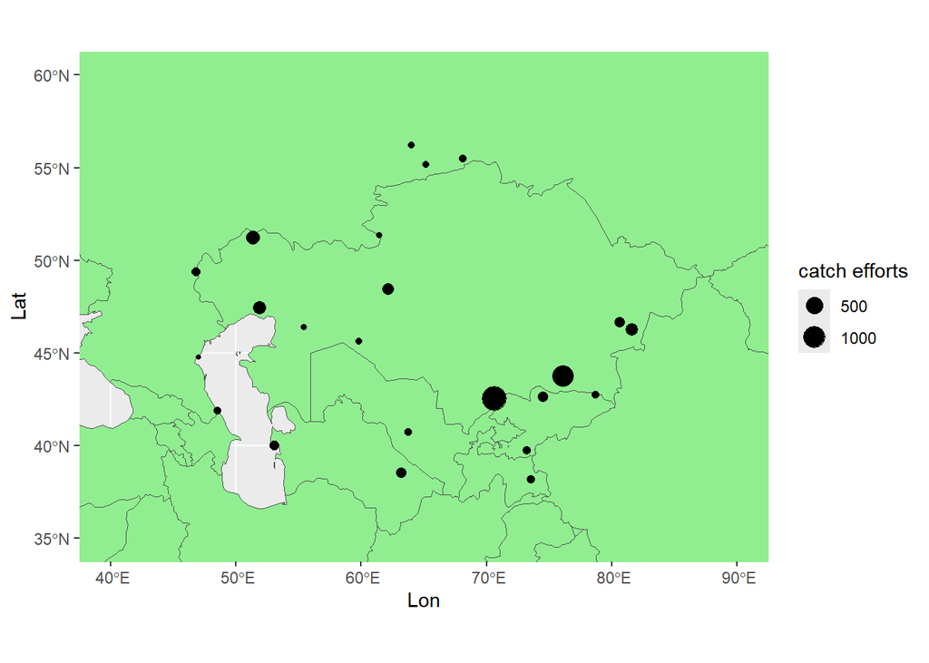

- **Phyl** - “пеночки”
- **Acro** - “камышевки”
- **Fice** - “мухоловки”

Чтобы не путать с “экологическими” группами видов буду использовать термин “географическая группа”

Вот состав этих географических групп.

Географическая группа 1: Phyl_trol, Phyl_inor, Acro_scir, Acro_dume, Acro_agri, Hipp_cali.

Географическая группа 2: Phyl_coll, Phyl_troc, Phyl_sibi, Acro_palu, Acro_scho, Fice_parv, Fice_hypo, Musc_stri.

## Карты отловов географическоой группы 1 (положительные значения CCA2)

Здесь и далее приводятся только ненулевые точки отловов. Размер точки пропорционален вероятности отлова. Желтые точки демонстрируют центроиды соответcnвующих полигонов.

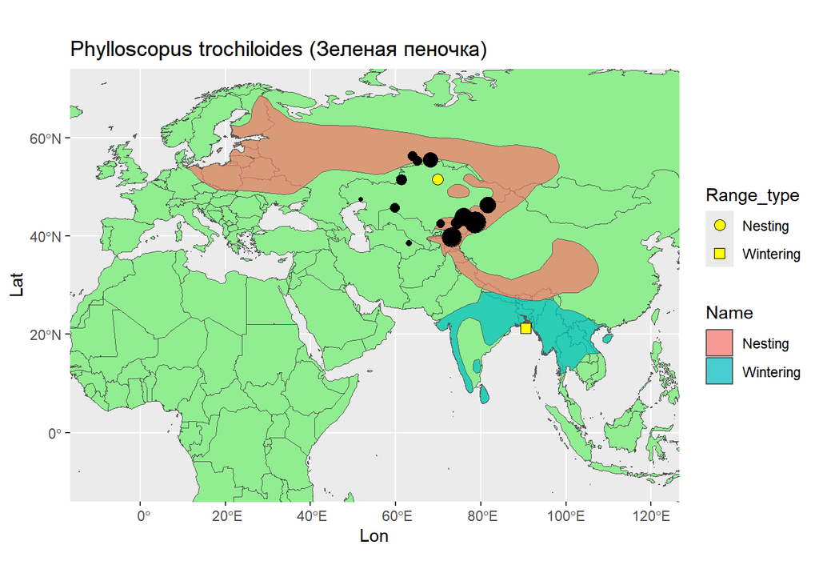

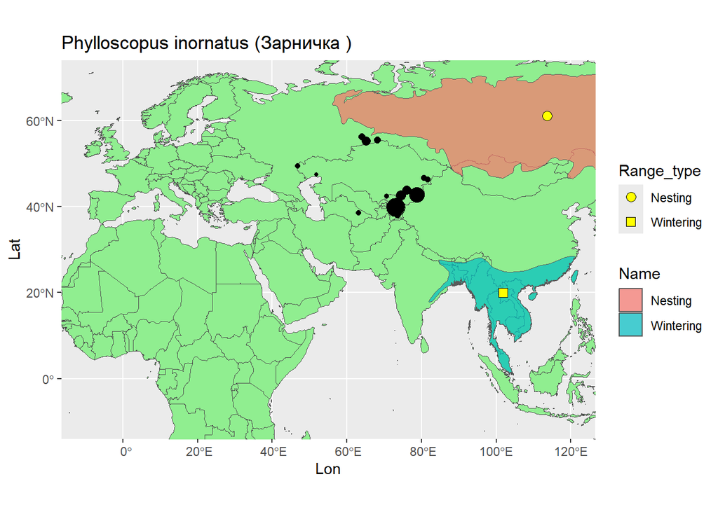

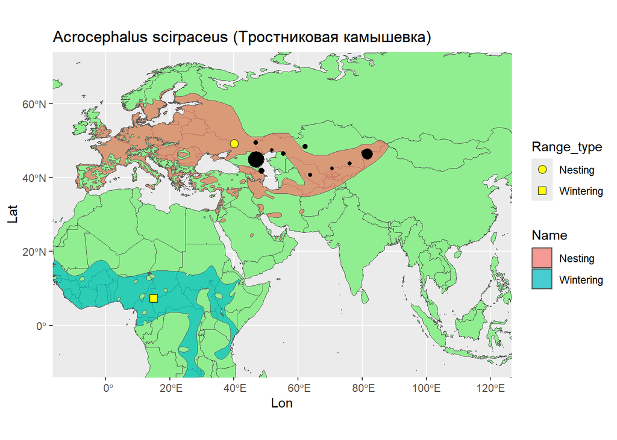

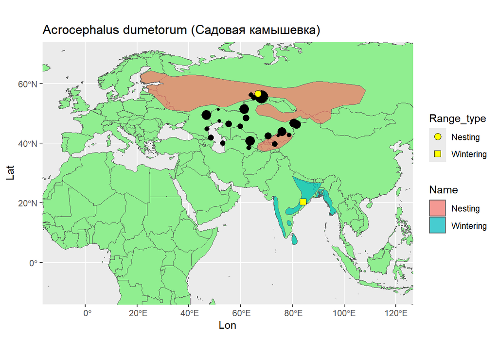

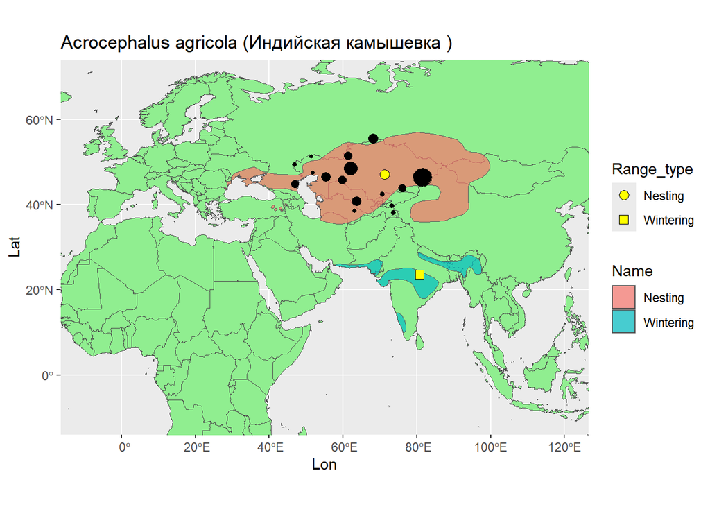

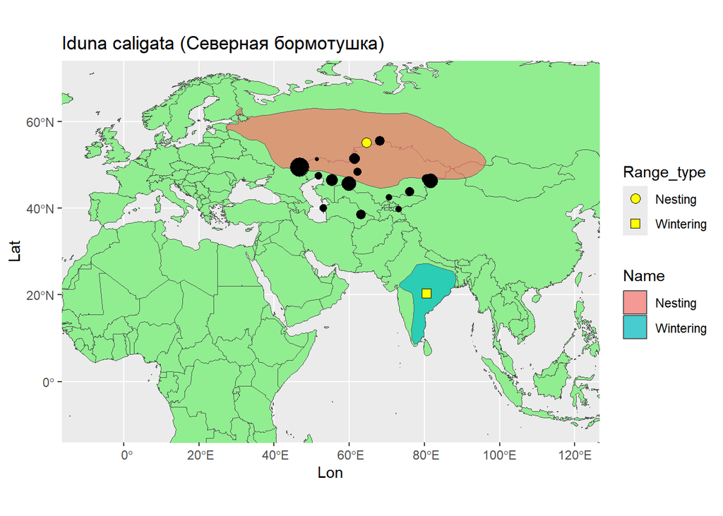

## Карты отловов географической группы 2 (отрицательные значения CCA2)

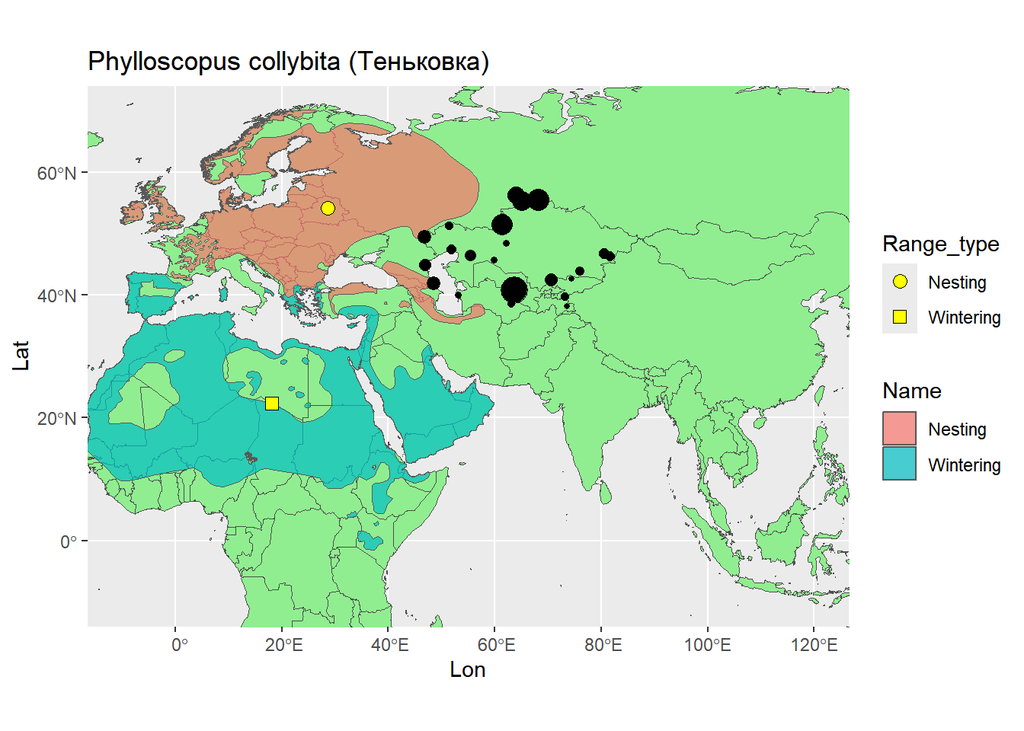

Здесь, как я понял, есть проблема с тем, что Теньковку (*Phylloscopus collybita*) могут путать с *Phylloscopus tristis* (как это по-русски?). Соответственно, привожу ареалы для второго вида.

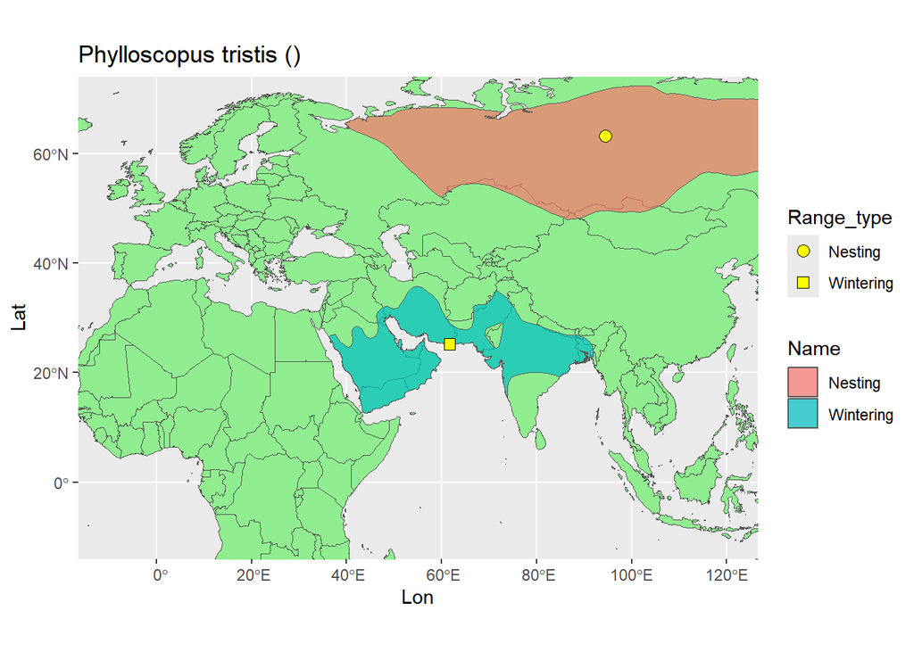

Здесь и далее (ситуация с двумя видами *Facedula*) я впадаю в ступор. Считать ли *Phylloscopus collybita* и *Phylloscopus tristis* одним видом? Если да, то я должен объединить их ареалы и, соответственно, будут иными центроиды. Или, что тоже, по-моему, правильно, мы считаем, что значения CCA2, которые описывают паттерн отлова видов отражают положение на ординации сразу двух видов. Дальше, пока, буду двигаться по второму пути.

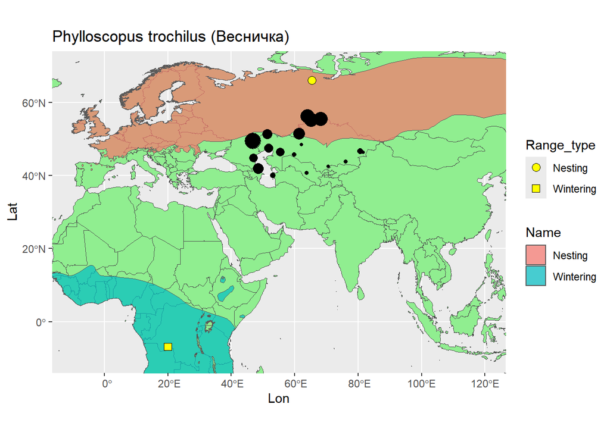

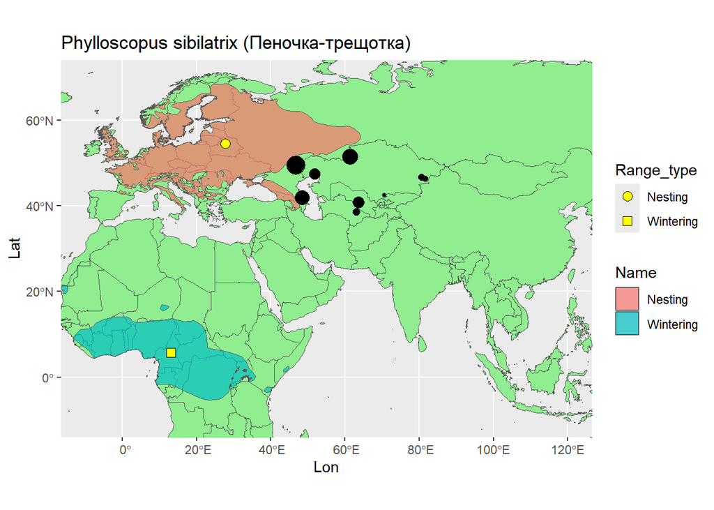

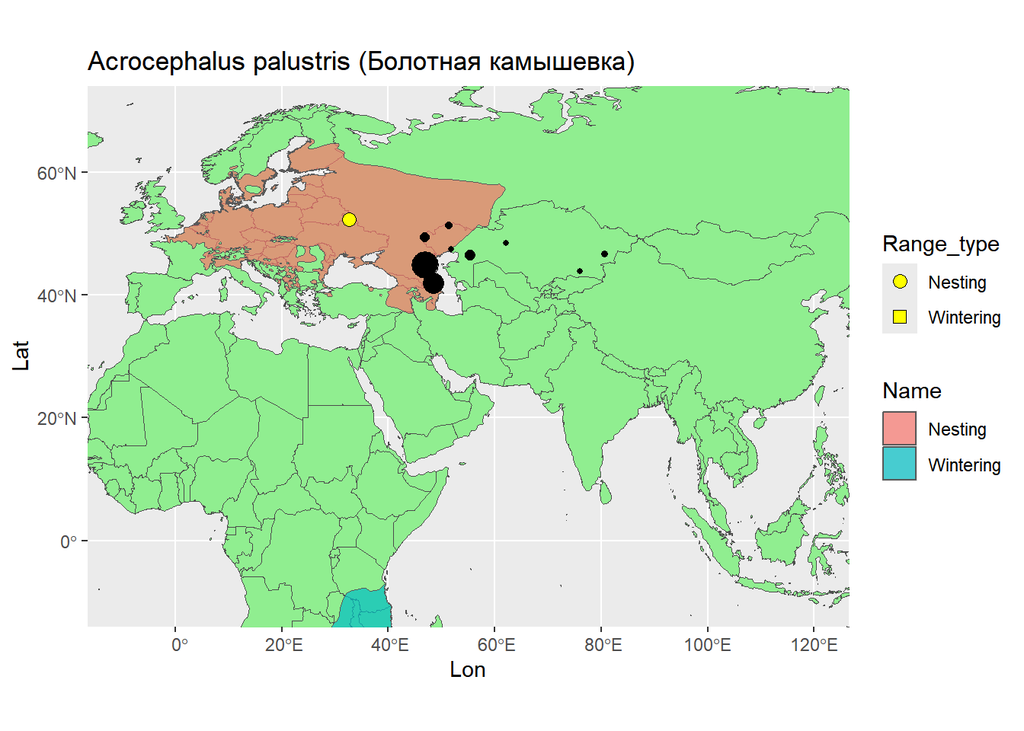

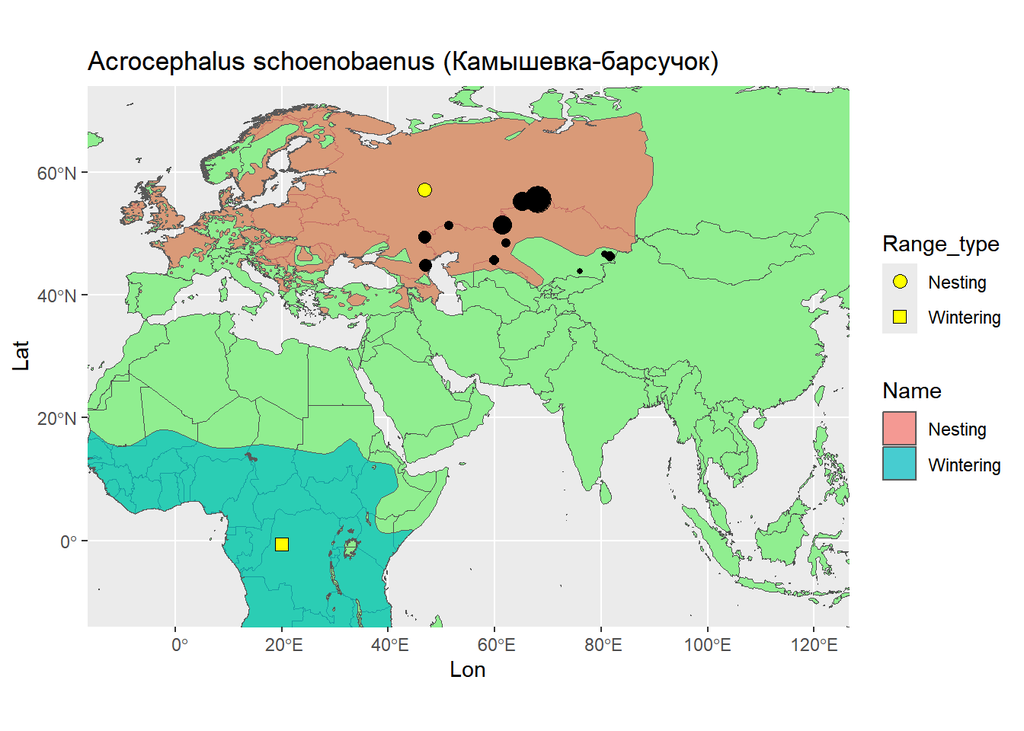

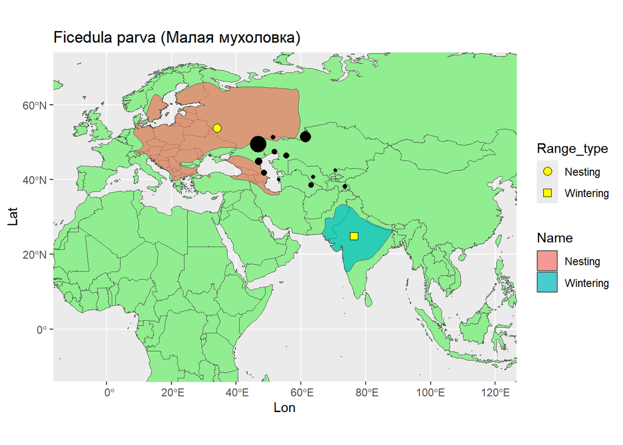

Аналогичная теньковкам ситуация. Вот карта для *Ficedula albicilla*

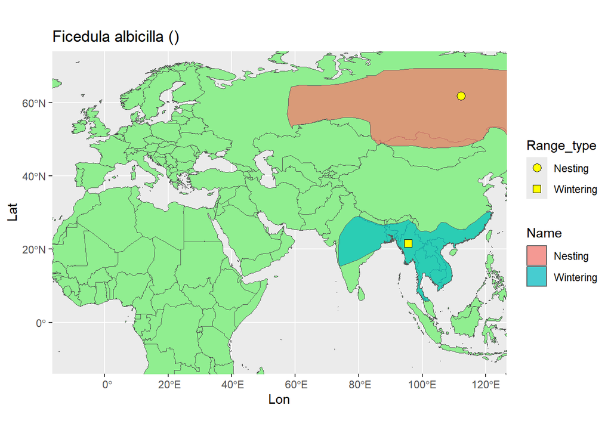

Здесь, возможно, чуть проще, чем в предыдущем случае, так как места зимовки у двух видов очень близки.

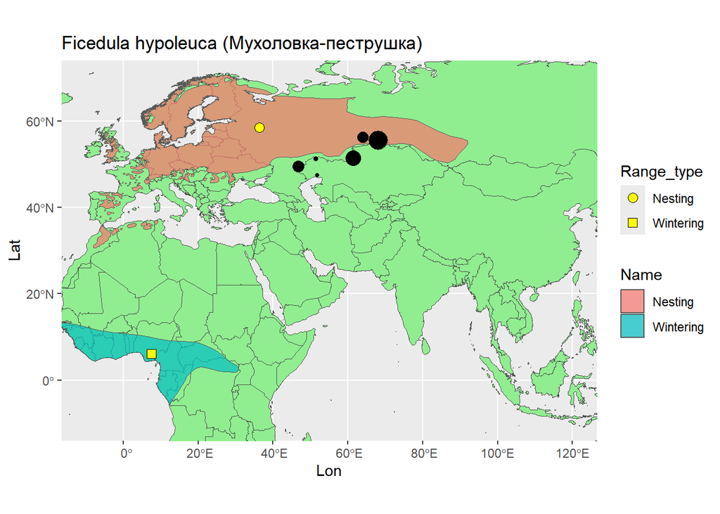

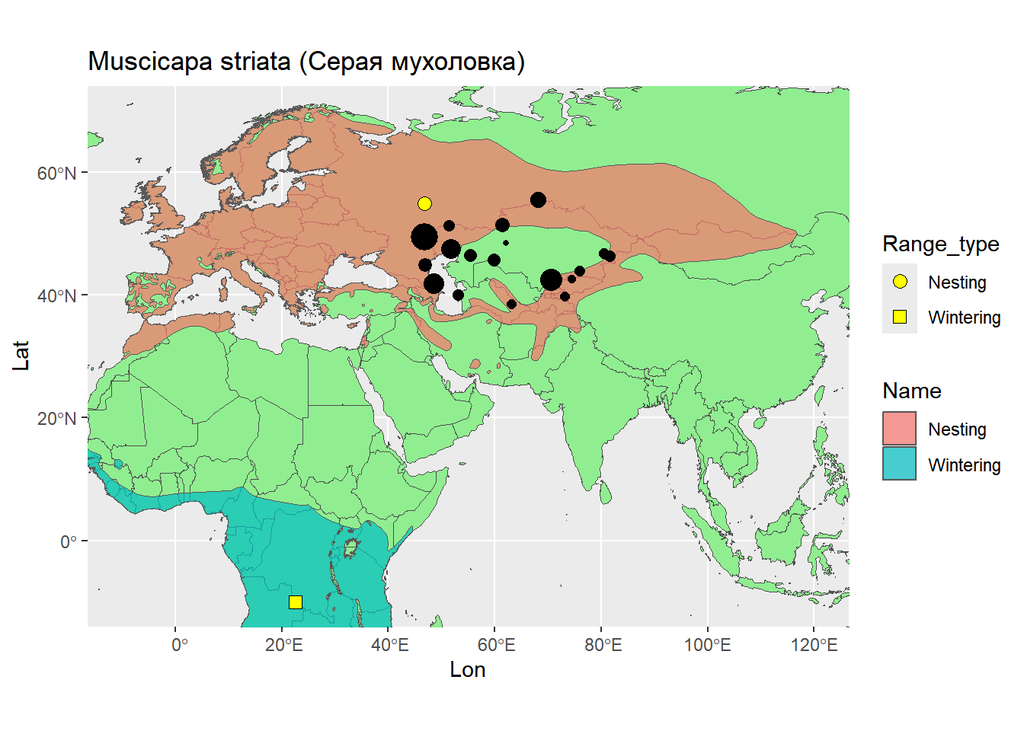

## Итого

Теперь внимательно смотрим на связь между ординацией видов по CCA2 и центроидами их мест зимовок

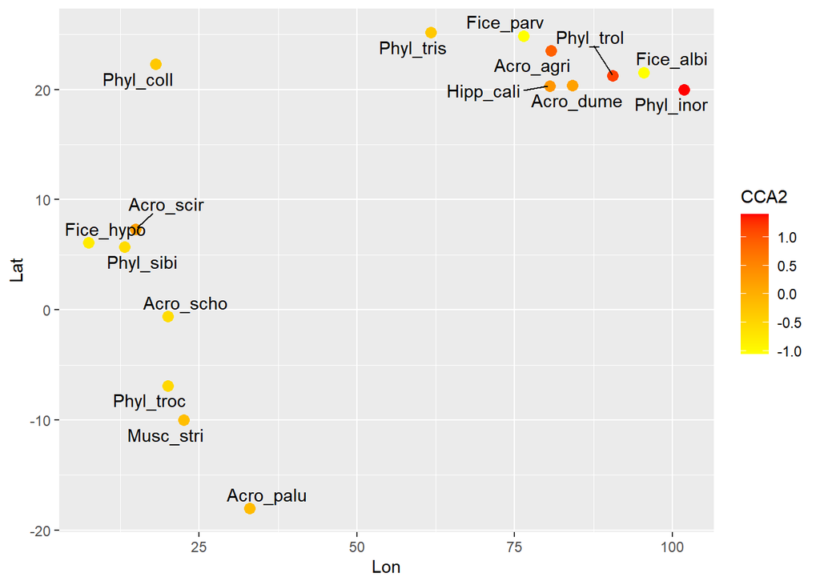

Видно, что вырисовываются два облака. Левое это африканские зимовщики, правое - Индо-Азиатские зимовщики. Те виды, что зимуют в Африке, в основном, имеют отрицательные нагрузки по ССА2 Большинство видов, что зимуют в Индии и Азии имеют положительные нагрузки по ССА2.

Эту картинку лучше смотреть вот так

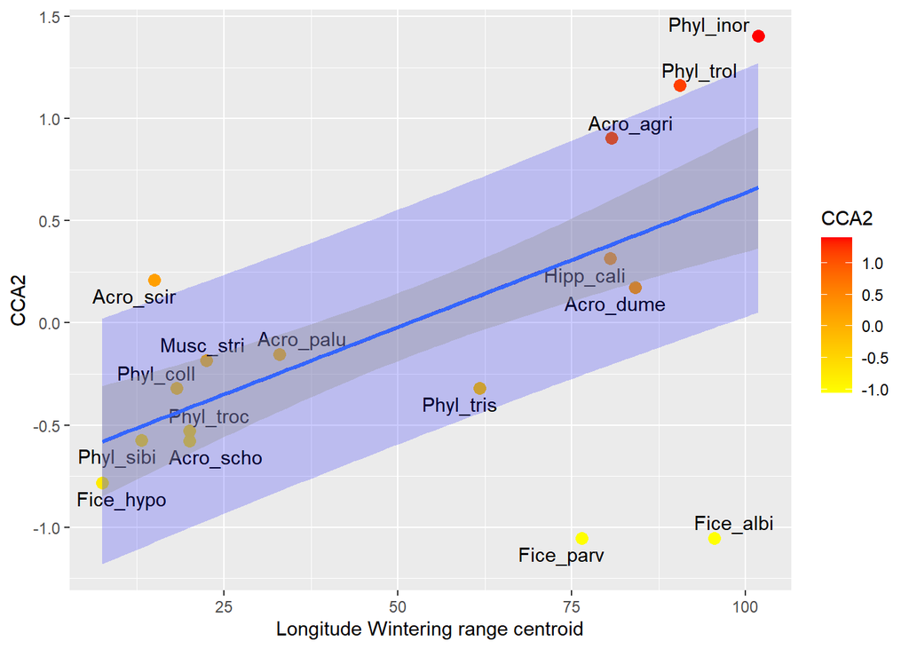

Здесь вписана робустная регрессия (т.е. линия, проходящая наилучшим образом через наиболее выраженное облако точек, типа основную тенденцию). Здесь я привел помимо 95% доверительного интервала для самой линии регрессии, еще и 90% интервал предсказания. Почему 90%? Чтобы хоть что-то было видно, чисто валюнтаристски. Короче говоря, в этот интервал должно попадать 90% предсказанных моделью значений, те, которые не попадают, - это аутлаеры, которые не вписываются в общую тенденцию.

Смысл всего этого заключается в том, что “нулевая модель” для рассуждений, как мне кажется, заключается в том, что куда ты летишь (на запад в Африку или на восток в Азию) определяет то, где тебя больше ловят (ССА2). Но! аутлаеры - это в некотором смысле “уроды”, которые летят вопреки. Может это именно то, что мы ищем? Эти аутлаеры что-то значат?